# How Do Users Review Spotify?

Analyzing Emotion, Topics, and Platform Replies Using Text as Data and Logistic Regression

Yihan Chen

Georgetown University

2025-04-29

# 1. Introduction

Spotify has been the most popular music streaming platform. On the Google Play Store, users leave public reviews about the app—yet only a few ever receive an official reply from Spotify.

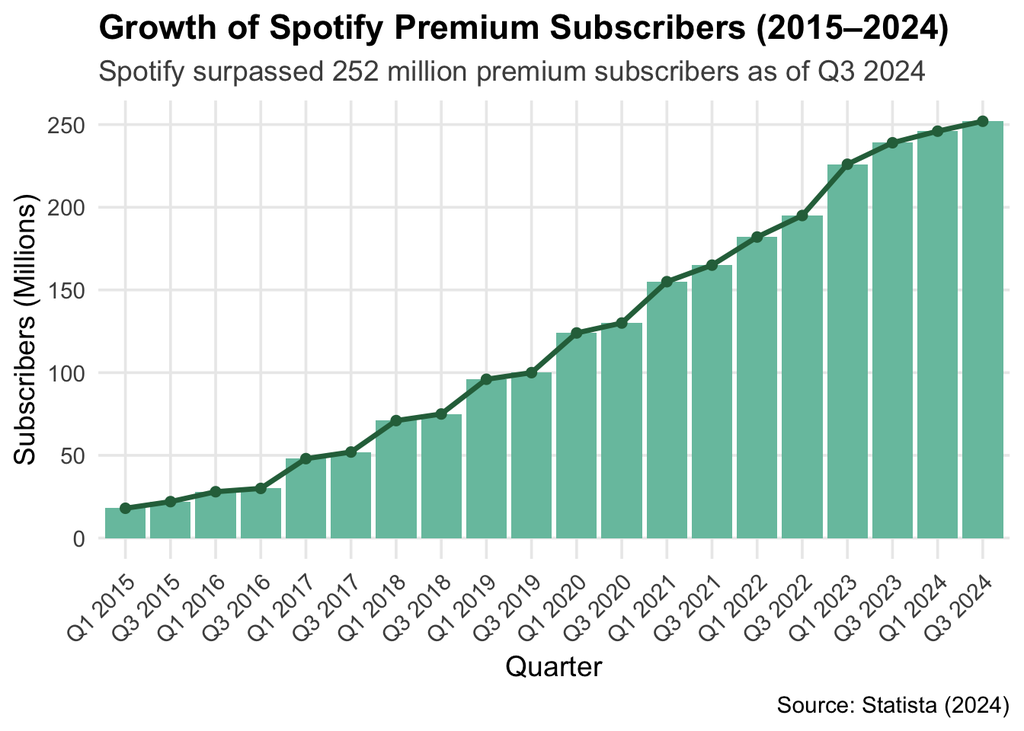

**Goals**:

- **(1) Business Strategy Perspective**: Analyze user-generated reviews to get key experience themes and sentiment patterns, to improve app functionality, user satisfaction, and retention.
- **(2) Digital Platform Governance Perspective**: Provide insights into Spotify’s public engagement practices, including reply prioritization and transparency considerations.

## 1.1 Research Questions

- **RQ1**: How do Spotify users describe their **experience** in written reviews?

  **H1**: Most reviews focus on **app functionality, usability, and technical performance** rather than music content.
- **RQ2**: Which review **topics or tones** are more likely to receive an **official reply**—and what does this reveal about platform priorities or transparency?

  **H2**: Reviews that express **dissatisfaction**, particularly those mentioning **technical issues or account problems**, are more likely.

## 1.2 Dataset

- 61,594 Spotify user reviews scraped from Google Play (2022 Kaggle dataset).
- Key fields collected:
  - **Star Rating** (1–5)
  - **Review Text**
  - **Review Timestamp**
  - **Number of Thumbs-up**
  - **Official Reply** (if any)

Deeper information needed for meaningful analysis is not directly available. Specifically:

- **Review Categories**: Does the review focus on App Experience or something else (e.g., music content)?
- **Review Topics**: Is the review about technical issues, UX features, account problems, or other concerns?
- **Sentiment and Emotions**: Does the review convey joy, anger, frustration, or satisfaction?
- **Reply Status**: Which reviews received an official response (0/1)?

## 1.3 Methodology

- **Manual Annotation:**  
  Hand-labeled 2,000 reviews into categories (e.g., App Experience vs. Other) for supervised learning.
- **Supervised Machine Learning:**
  - Models: Naïve Bayes, SVM (linear kernel), and Lasso (logistic regression)
  - Features: TF-IDF weighted matrices and GloVe word embeddings
  - Cross-validation: 5-fold CV for hyperparameter tuning (e.g., SVM cost, Lasso lambda)
- **Unsupervised Topic Modeling:**
  - LDA (Latent Dirichlet Allocation) applied to App Experience reviews
  - Number of topics selected based on interpretability (K = 6)
- **Sentiment Analysis:**
  - NRC lexicon mapping to classify emotions (e.g., anger, joy, sadness) at the review level
- **Logistic Regression Analysis:**
  - Investigated predictors of official reply likelihood using review sentiment, topic, and length

# 2. Labeling Results

## 2.1 Supervised Machine Learning: Review Category Prediction

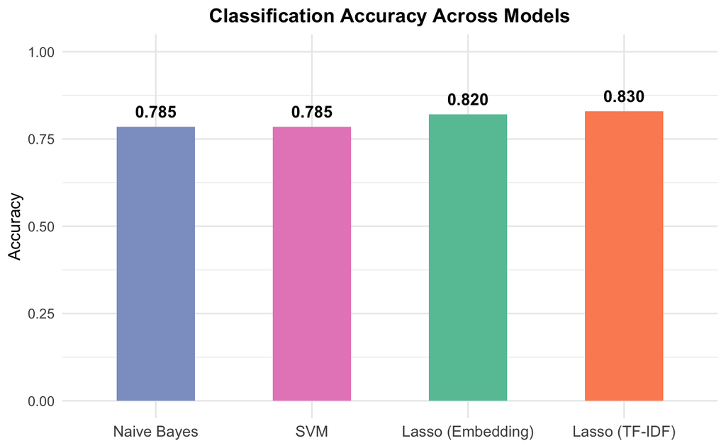

| Metric | TF-IDF Lasso | Word Embedding Lasso |
| --- | --- | --- |
| Accuracy | 0.83 | 0.82 |
| Kappa | 0.648 | 0.613 |
| Precision | 0.868 | 0.837 |
| Recall | 0.846 | 0.878 |
| F1 Score | 0.857 | 0.857 |
| Balanced Accuracy | 0.826 | 0.802 |

- **TF-IDF Lasso** slightly outperformed Word Embedding Lasso across multiple evaluation metrics.
- Selected **TF-IDF Lasso** for full dataset classification based on higher accuracy and better balanced performance.

## 2.2 Unsupervised Topic Modeling: Sub-Themes in App Experience Reviews

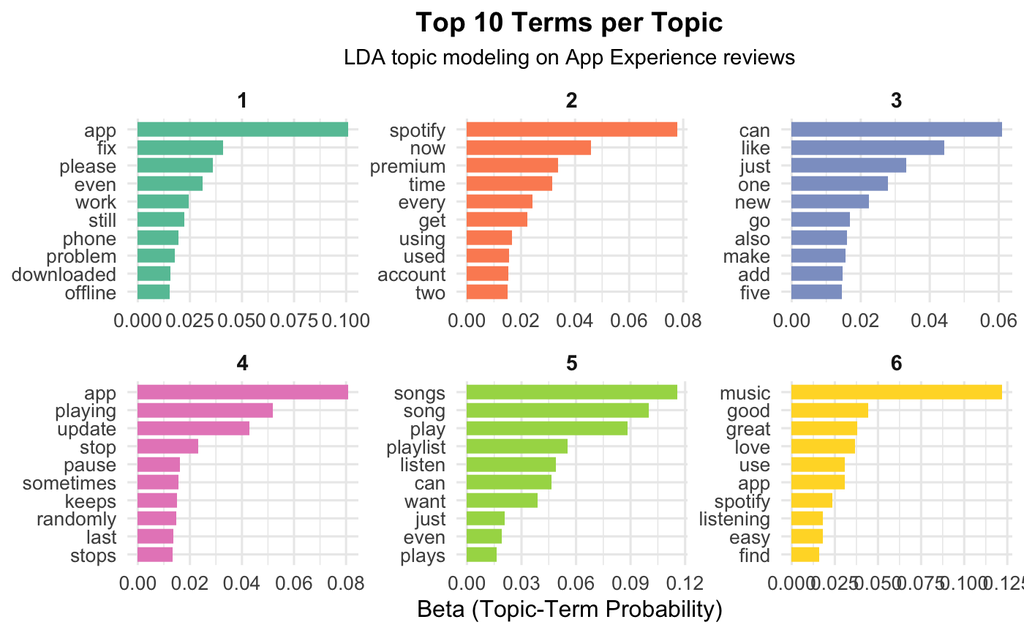

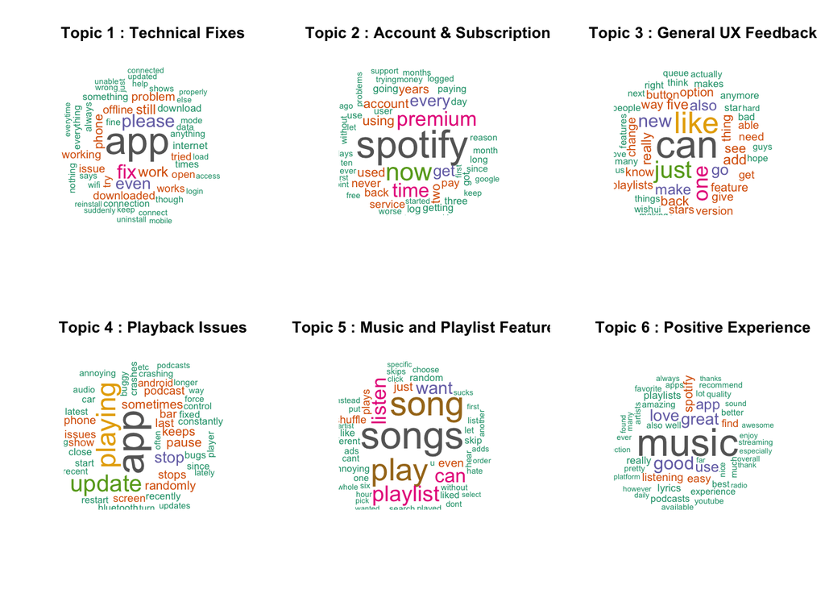

- **LDA Topic Modeling** (K = 6) revealed key sub-themes within App Experience feedback.

# 3. Descriptive Overview

## 3.1 Sentiment, Reply Rate, Label

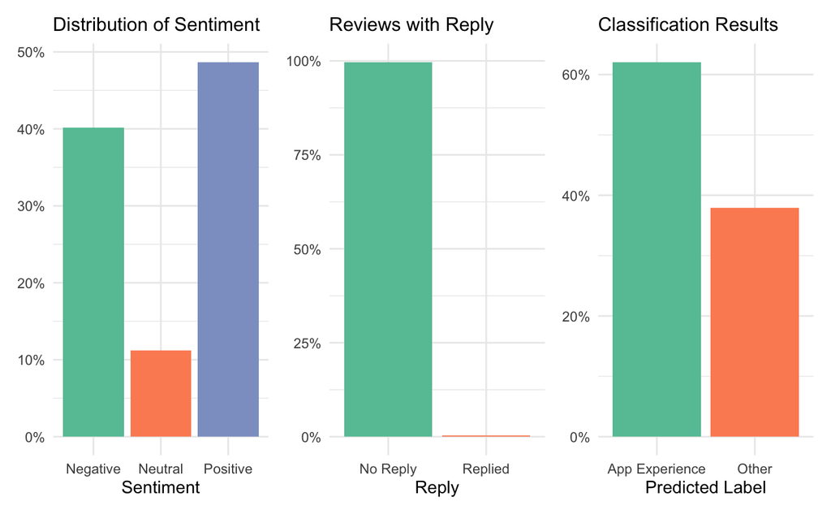

## 3.2 Sentiment-Reply Patterns by Category

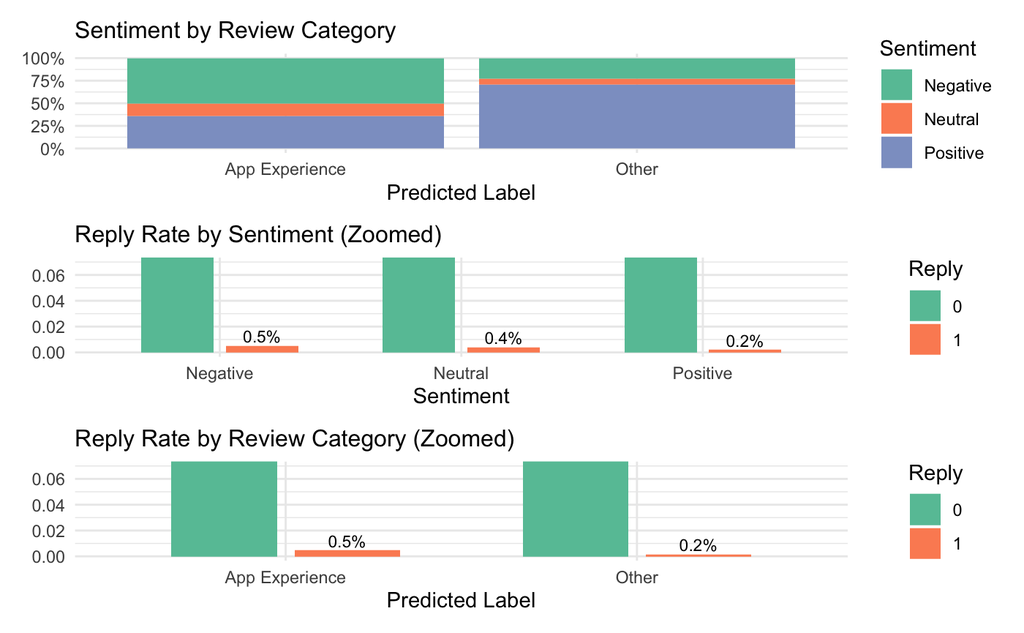

- **App Experience** reviews are more likely to have negative star ratings.
- **Negative** reviews are more likely to receive a reply than **positive** ones.
- Reviews about **App Experience** are more likely to be replied to than reviews about other topics.

## 3.3 Duplicate Reviews

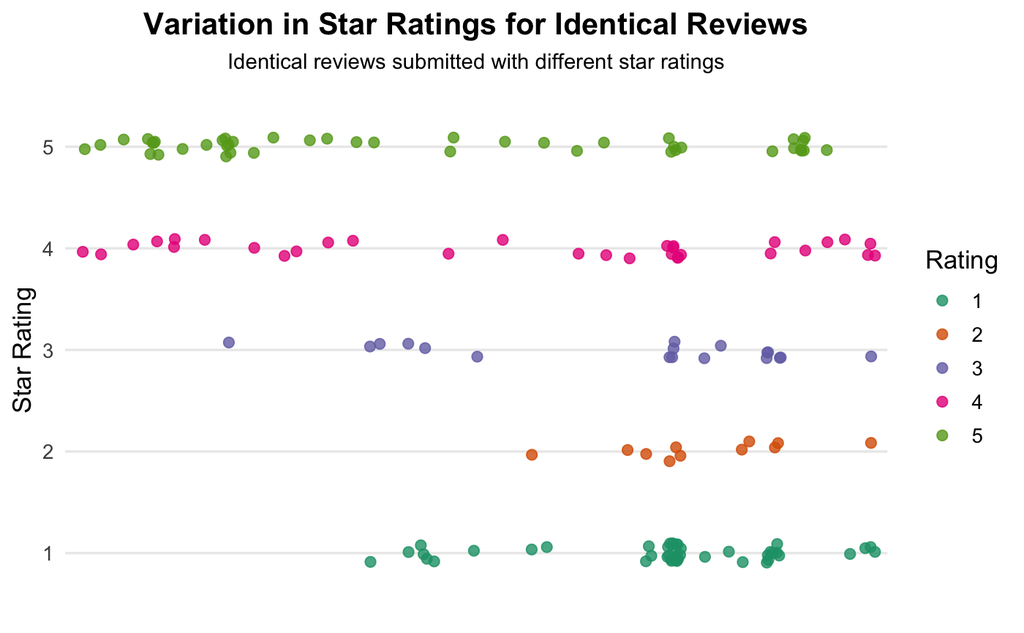

- One interesting observation is that the same review can get different ratings.

## 3.4 Emotion Score

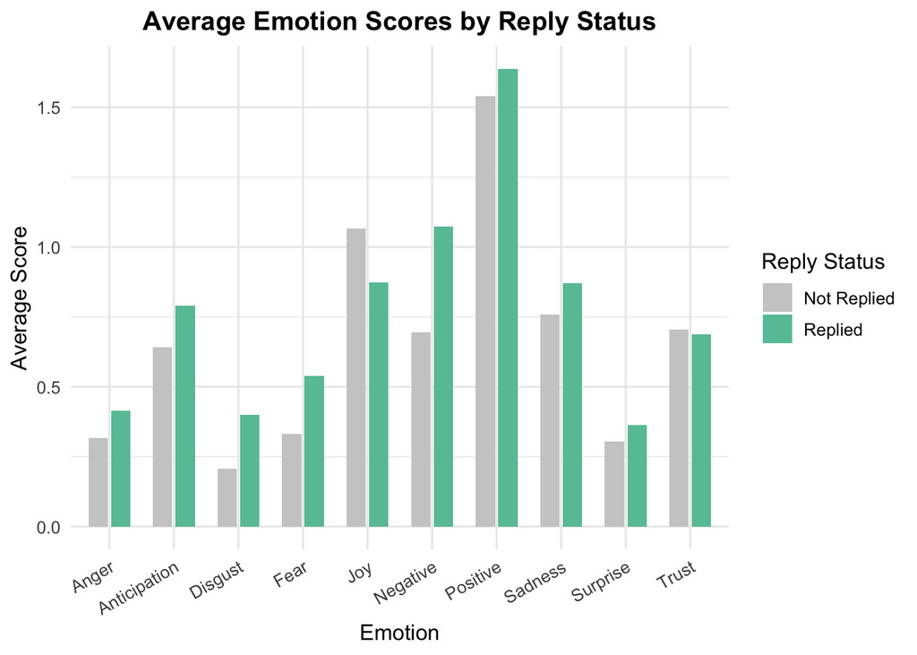

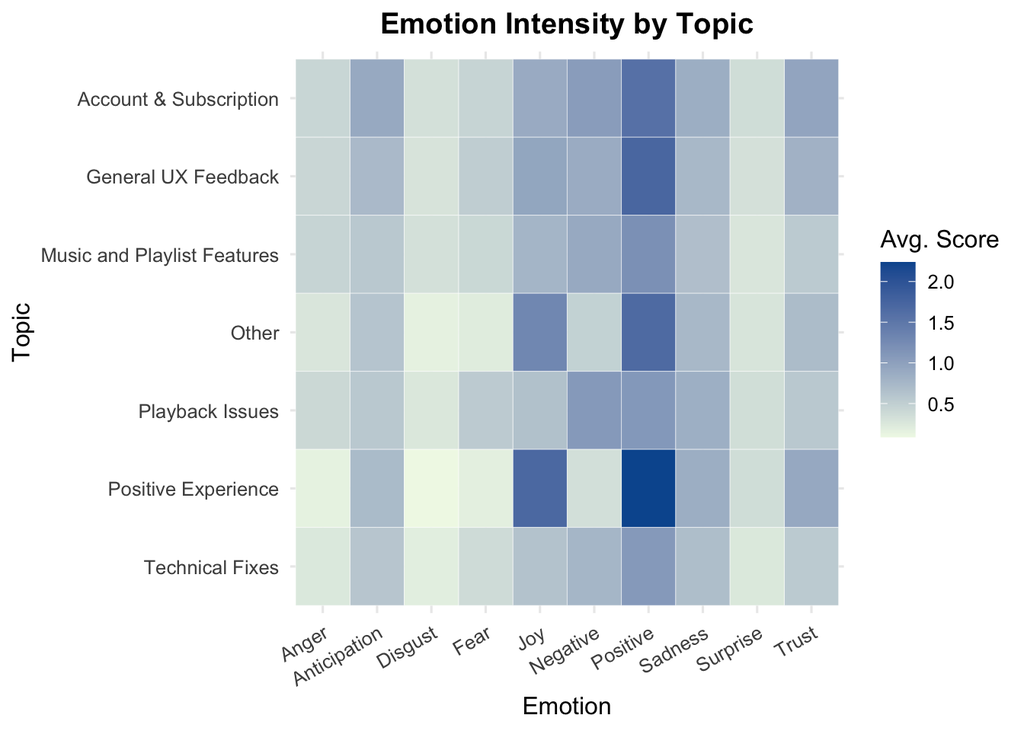

- **Disgust**, **Fear**, and **Negative** emotions are **higher** in reviews that received a **reply**.
- Reviews expressing **Joy** and **Trust** are **less likely** to receive a reply.

## 3.5 Competitors

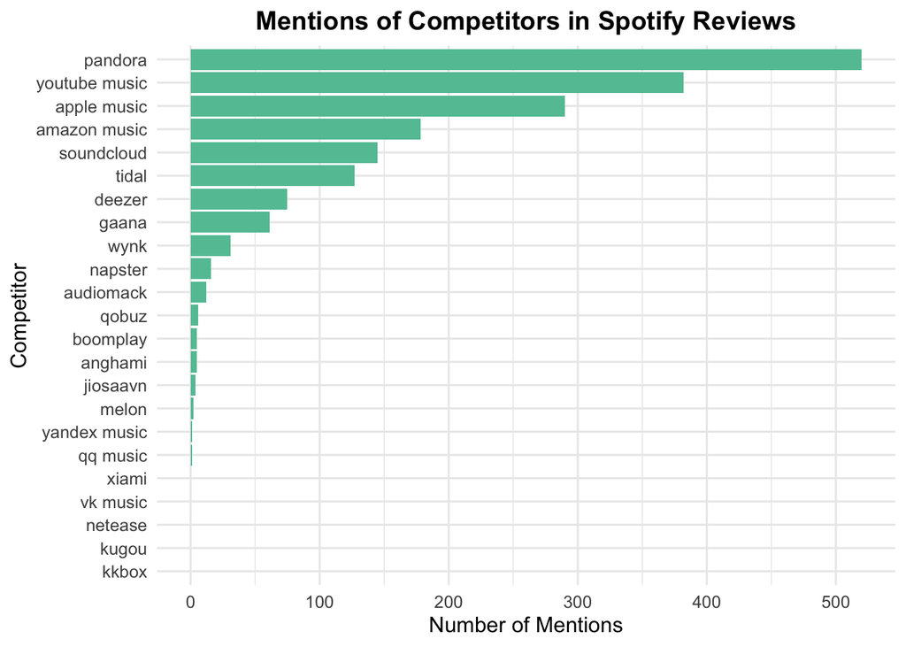

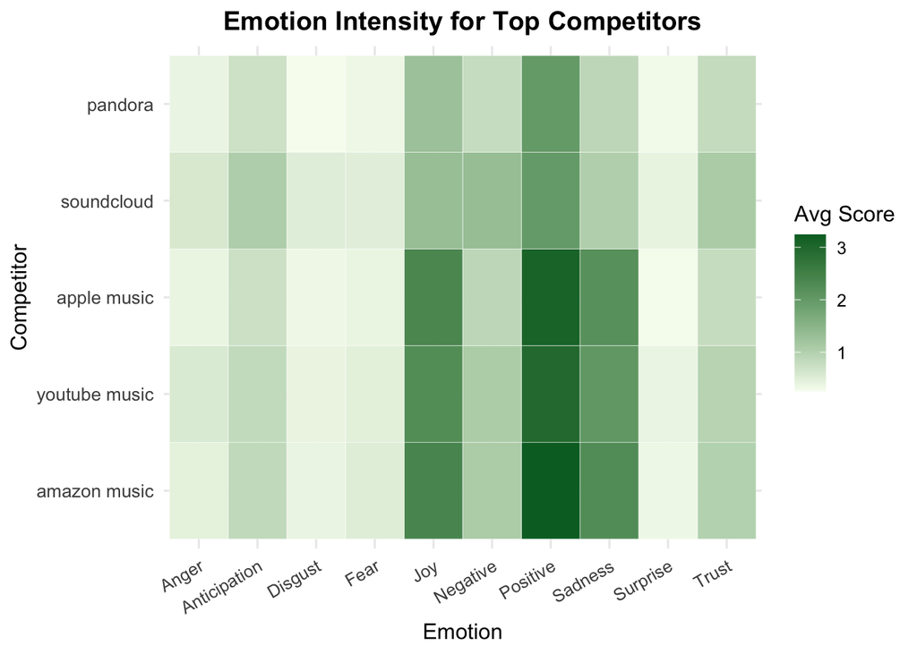

- Apple Music, YouTube Music and Amazon Music clearly dominate in emotional engagement (**joy**, **positive** and **sadness**).

# 4. Reply Analysis

## 4.1 Logistic Regression

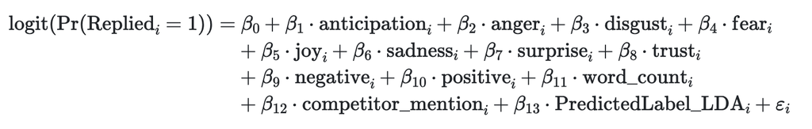

Are emotion, word count, competitor-mention, and topic labels linked to whether a user gets a Spotify reply?

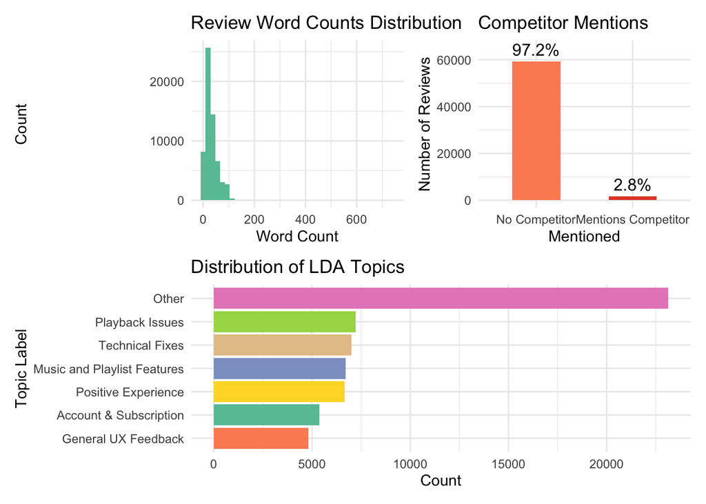

## 4.2 Regression Result

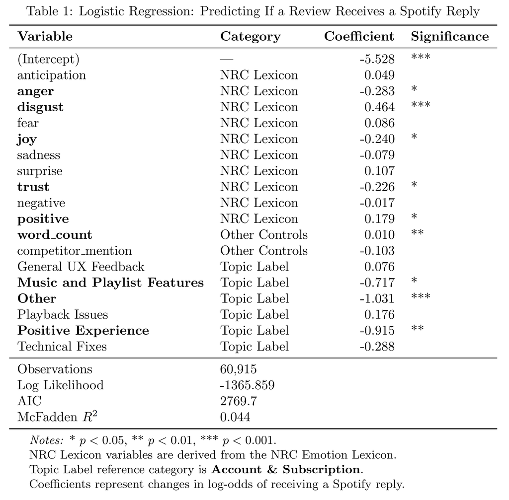

## 4.3 SMOTE Adjustment for Reply Imbalance

To evaluate whether findings are robust to imbalance, I re-estimated the reply model using SMOTE-balanced data.

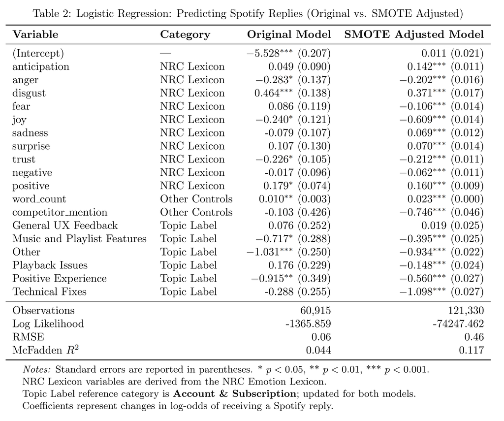

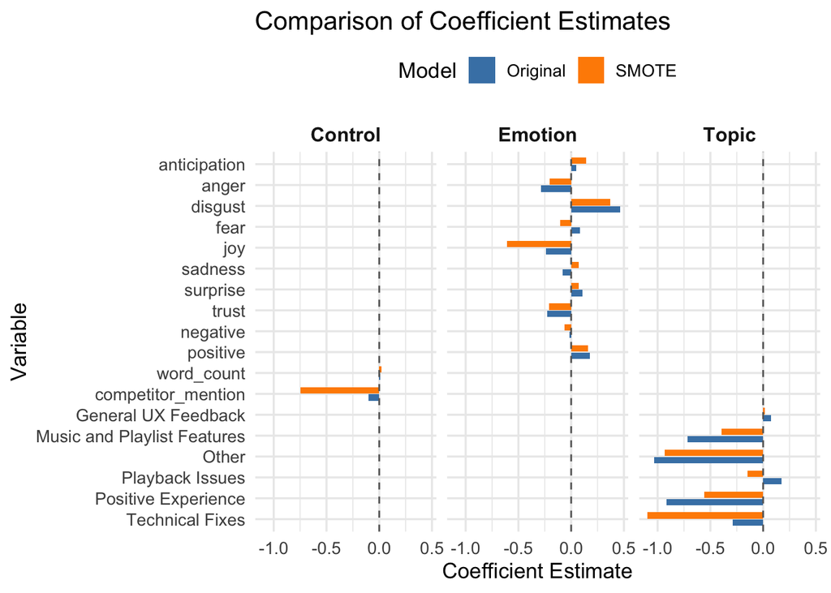

# 5. Discussion

- ✅ Most users complain about **app function**, not music (**RQ1 supported**)
- 📉 Spotify replies mostly to **negative, detailed reviews** (disgust, account issues)
- 💬 **Joyful/trusting reviews** are often ignored—missed opportunity to engage satisfied users
- 🛠️ Reply strategy is **reactive (problem)**, not proactive (praise) (**RQ2 supported**)
- 🔄 SMOTE results confirm key findings are **robust**
- ⚠️ **Competitor mentions** evoke strong emotion—signal of potential **churn risk**

## 5.1 Limitations

- 🎯 **Classification**:  
  Word embedding models underperformed compared to TF-IDF Lasso; further tuning or larger embedding datasets may improve results.
- 🧩 **Topic Modeling**:  
  Some topics show overlap and limited distinctiveness; better preprocessing, validarion, or alternative models could enhance separation.
- 🗑️ **Duplicates**:  
  Although duplicate reviews were retained, their short text length may reduce analysis quality; impact is limited given the small number (~270).
- 🎵 **Word Clouds**:  
  Repetitive terms like “song” and “songs” appeared separately - minor stemming or tokenization issues.
- 📉 **Regression Sample Size**:  
  The number of replied reviews was extremely small (<3.5%), limiting statistical power before adjustment.
- 🏛️ **Policy Implications**:  
  Although reply patterns hint at engagement priorities, deeper exploration is needed to fully assess platform transparency and accountability.

## 5.2 Lessons Learned and Next Steps

- Understanding models, focusing on details, and building a structured workflow greatly improved project quality
- Future work could explore more advanced models and deeper policy implications